# Modelo Lineal Clásico

Trabajo 1: Modelos Lineales

Bladimir Morales Torrez

Enero 2022

# Datos a ser estudiados

En el presente trabajo se realizará un modelo de regresión lineal múltiple que explique la variable de respuesta Esperanza de vida de los diferentes países del mundo y que estan registrados en el Banco Mundial, cabe mencionar que los datos fueron procesados antes de su utilización tomando en cuenta que hacen referencia al año 2018 y solo se tomo en cuenta los países que cuentan con la información tanto la variable de respuesta como las explicativas.

La variable de respuesta es:

$Y=$Esperanza de vida al nacer, total (años).

Las variables explicativas $X_i$ son:

- Tasa de mortalidad, adultos (por cada 1.000 adultos)
- Tasa de fertilidad, total (nacimientos por cada mujer)
- Superficie (kilómetros cuadrados)
- Crecimiento del PIB (% anual)
- Acceso a la electricidad (% de población)
- Desempleo, total (% de la población activa total) (estimación modelado OIT)
- Emisiones de CO2 (kt)
- Emisiones de metano (kt de equivalente de CO2)
- Emisiones de óxido nitroso (miles de toneladas métricas de equivalente de CO2)
- Gasto público en educación, total (% del PIB)

La información fue obtenida del banco de datos que tiene el Banco Mundial y fue descargada del siguiente enlace (https://databank.bancomundial.org/source/world-development-indicators).

## Análisis descriptivo

```r
bd_pob1<-read_xlsx("./data/bd_poblacion.xlsx")
bd_esp_vida<-bd_pob1[,3:ncol(bd_pob1)]
```

En primer lugar se visualizará el comportamiento de la variable respuesta Esperanza de vida al nacer mediante el histograma.

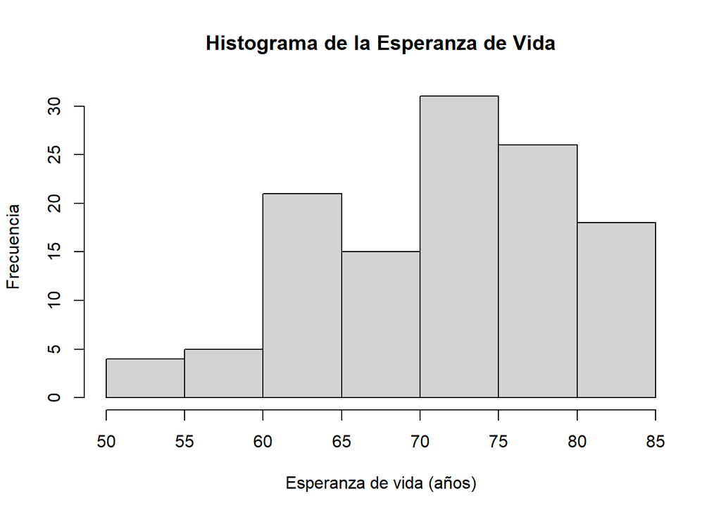

```r
hist(bd_esp_vida$esp_vida,main = "Histograma de la Esperanza de Vida",
     xlab = "Esperanza de vida (años)",
     ylab = "Frecuencia")
```

La esperanza de vida tiene los siguiente estadísticos:

```r
summary(bd_esp_vida$esp_vida)
```

```
##    Min. 1st Qu.  Median    Mean 3rd Qu.    Max.
##   52.80   64.88   73.12   71.45   76.80   83.75
```

Ahora se visualizará las correlaciones que tienen las variables en estudio.

```r
cor(bd_esp_vida)
```

```
##                        esp_vida fertilidad   superficie crecimiento_pib
## esp_vida             1.00000000 -0.8337722  0.097108433    -0.159705902
## fertilidad          -0.83377219  1.0000000 -0.058692402     0.130598023
## superficie           0.09710843 -0.0586924  1.000000000    -0.007519633
## crecimiento_pib     -0.15970590  0.1305980 -0.007519633     1.000000000
## acceso_electricidad  0.81630543 -0.8276405  0.076346040    -0.139233006
## desempleo           -0.01355599 -0.1568483  0.004480272    -0.296474595
## co2                  0.11255860 -0.1294939  0.637828070     0.094004929
## metano               0.09758181 -0.1152920  0.801056355     0.086497462
## oxido_nitroso        0.07486037 -0.0878121  0.808261171     0.099278939
## gasto_educacion      0.22300587 -0.2173722  0.039475663    -0.121371920
## mortalidad          -0.95411977  0.7147177 -0.105701294     0.102297152
##                     acceso_electricidad    desempleo         co2      metano
## esp_vida                     0.81630543 -0.013555988  0.11255860  0.09758181
## fertilidad                  -0.82764053 -0.156848316 -0.12949392 -0.11529199
## superficie                   0.07634604  0.004480272  0.63782807  0.80105635
## crecimiento_pib             -0.13923301 -0.296474595  0.09400493  0.08649746
## acceso_electricidad          1.00000000  0.148661600  0.10758814  0.10942308
## desempleo                    0.14866160  1.000000000 -0.03838354 -0.05818316
## co2                          0.10758814 -0.038383545  1.00000000  0.93281498
## metano                       0.10942308 -0.058183162  0.93281498  1.00000000
## oxido_nitroso                0.06833360 -0.058317428  0.93701023  0.98564851
## gasto_educacion              0.22673477  0.219033651 -0.04034134 -0.04990278
## mortalidad                  -0.76893603  0.106615112 -0.14004220 -0.13180976
##                     oxido_nitroso gasto_educacion mortalidad
## esp_vida               0.07486037      0.22300587 -0.9541198
## fertilidad            -0.08781210     -0.21737220  0.7147177
## superficie             0.80826117      0.03947566 -0.1057013
## crecimiento_pib        0.09927894     -0.12137192  0.1022972
## acceso_electricidad    0.06833360      0.22673477 -0.7689360
## desempleo             -0.05831743      0.21903365  0.1066151
## co2                    0.93701023     -0.04034134 -0.1400422
## metano                 0.98564851     -0.04990278 -0.1318098
## oxido_nitroso          1.00000000     -0.04343349 -0.1020348
## gasto_educacion       -0.04343349      1.00000000 -0.1227976
## mortalidad            -0.10203477     -0.12279756  1.0000000
```

Se puede observar que la variable de respuesta esperanza de vida, cuenta con un alto grado de correlación con las variables de fertilidad, acceso_electricidad y mortalidad, lo cual se puede visualizar en el siguiente gráfico que explica la relación lineal que pueden tener las variables en estudio.

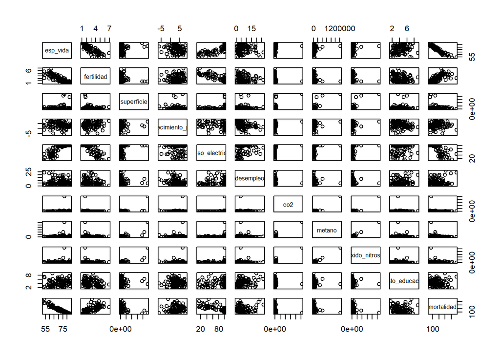

```r
plot(bd_esp_vida)
```

# Estimación

En esta sección se estimará un modelo lineal clásico con las 10 covariables propuestas, donde la variable respuesta es la esperanza de vida, el fin será obtener un modelo óptimo el cual por un lado pueda explicar de mejor manera la variable de respuesta y por otro lado que sea parsimonioso. Para esto se tomará los siguientes criterios:

- Pruebas de hipótesis para los coeficientes
- Menor Criterio de Información de Akaike AIC
- Análisis de varianza ANOVA

Primero se estima el modelo con toda la información.

```r
mod<-lm(esp_vida~.,data=bd_esp_vida)
summary(mod)
```

```
##
## Call:
## lm(formula = esp_vida ~ ., data = bd_esp_vida)
##
## Residuals:
##     Min      1Q  Median      3Q     Max
## -3.3836 -0.8878  0.2011  0.9053  3.0928
##
## Coefficients:
##                       Estimate Std. Error t value Pr(>|t|)
## (Intercept)          8.718e+01  1.403e+00  62.141  < 2e-16 ***
## fertilidad          -1.859e+00  1.923e-01  -9.664  2.5e-16 ***
## superficie           3.923e-07  2.094e-07   1.873  0.06373 .
## crecimiento_pib     -1.055e-01  5.331e-02  -1.978  0.05041 .
## acceso_electricidad -5.145e-03  1.012e-02  -0.508  0.61236
## desempleo           -1.532e-02  2.872e-02  -0.533  0.59492
## co2                  4.723e-07  5.244e-07   0.901  0.36979
## metano              -1.852e-05  6.881e-06  -2.692  0.00823 **
## oxido_nitroso        2.291e-05  1.795e-05   1.277  0.20442
## gasto_educacion      2.881e-01  9.217e-02   3.126  0.00227 **
## mortalidad          -6.381e-02  2.634e-03 -24.229  < 2e-16 ***
## ---
## Signif. codes:  0 '***' 0.001 '**' 0.01 '*' 0.05 '.' 0.1 ' ' 1
##
## Residual standard error: 1.46 on 109 degrees of freedom
## Multiple R-squared:  0.9671, Adjusted R-squared:  0.9641
## F-statistic: 320.8 on 10 and 109 DF,  p-value: < 2.2e-16
```

En el resumen del modelo lineal clásico se tiene un coeficiente de determinación ajustado $R^2_{ajus}=0.9641$, concluyendo que el modelo tiene una alta calidad. También se puede observar que se tiene un estadístico F grande lo cual rechaza la hipóstesis nula, teniendo así evidencia estadística para rechazar la hipótesis nula.

$$H_0: \beta_1=\beta_2=...=\beta_p=0$$
$$H_1: \beta_j\neq0\;\text{ ; para algún }j=1,...,p$$

Por otro lado el software R con la función `stepAIC()` realiza iteraciones combinando todos los modelos lineales posibles, tomando en cuenta el menor valor del Criterio de Información de Akaike (AIC).

```r
stepAIC(mod,trace = F)
```

```
##
## Call:
## lm(formula = esp_vida ~ fertilidad + superficie + crecimiento_pib +
##     metano + oxido_nitroso + gasto_educacion + mortalidad, data = bd_esp_vida)
##
## Coefficients:
##     (Intercept)       fertilidad       superficie  crecimiento_pib
##       8.641e+01       -1.772e+00        2.688e-07       -1.001e-01
##          metano    oxido_nitroso  gasto_educacion       mortalidad
##      -1.790e-05        3.212e-05        2.811e-01       -6.386e-02
```

Posterior de la búsqueda del menor AIC, se proporciona las siguientes variables explicativas: tasa de fertilidad, superficie, crecimiento_pib, metano, oxido nitroso, gasto en educación y mortalidad. Tomando en cuenta las mismas se ajusta nuevamente el modelo.

```r
mod1<-lm(esp_vida ~ fertilidad + superficie + crecimiento_pib + metano + oxido_nitroso +
    gasto_educacion+mortalidad, data = bd_esp_vida)
summary(mod1)
```

```
##
## Call:
## lm(formula = esp_vida ~ fertilidad + superficie + crecimiento_pib +
##     metano + oxido_nitroso + gasto_educacion + mortalidad, data = bd_esp_vida)
##
## Residuals:
##     Min      1Q  Median      3Q     Max
## -3.3025 -0.9141  0.1452  0.9828  3.2672
##
## Coefficients:
##                   Estimate Std. Error t value Pr(>|t|)
## (Intercept)      8.641e+01  5.926e-01 145.804  < 2e-16 ***
## fertilidad      -1.772e+00  1.505e-01 -11.775  < 2e-16 ***
## superficie       2.688e-07  1.639e-07   1.640  0.10381
## crecimiento_pib -1.001e-01  5.081e-02  -1.969  0.05139 .
## metano          -1.790e-05  6.574e-06  -2.723  0.00751 **
## oxido_nitroso    3.212e-05  1.547e-05   2.076  0.04018 *
## gasto_educacion  2.811e-01  8.979e-02   3.131  0.00222 **
## mortalidad      -6.386e-02  2.148e-03 -29.737  < 2e-16 ***
## ---
## Signif. codes:  0 '***' 0.001 '**' 0.01 '*' 0.05 '.' 0.1 ' ' 1
##
## Residual standard error: 1.449 on 112 degrees of freedom
## Multiple R-squared:  0.9667, Adjusted R-squared:  0.9646
## F-statistic: 464.8 on 7 and 112 DF,  p-value: < 2.2e-16
```

```r
mod2<-lm(esp_vida ~ fertilidad + metano + gasto_educacion+mortalidad, data = bd_esp_vida)
summary(mod2)
```

```
##
## Call:
## lm(formula = esp_vida ~ fertilidad + metano + gasto_educacion +
##     mortalidad, data = bd_esp_vida)
##
## Residuals:
##     Min      1Q  Median      3Q     Max
## -3.9495 -0.9213  0.2880  1.0082  3.1891
##
## Coefficients:
##                   Estimate Std. Error t value Pr(>|t|)
## (Intercept)      8.583e+01  5.860e-01 146.477  < 2e-16 ***
## fertilidad      -1.744e+00  1.552e-01 -11.240  < 2e-16 ***
## metano          -1.916e-06  1.142e-06  -1.678 0.096010 .
## gasto_educacion  3.328e-01  9.212e-02   3.613 0.000451 ***
## mortalidad      -6.384e-02  2.223e-03 -28.715  < 2e-16 ***
## ---
## Signif. codes:  0 '***' 0.001 '**' 0.01 '*' 0.05 '.' 0.1 ' ' 1
##
## Residual standard error: 1.51 on 115 degrees of freedom
## Multiple R-squared:  0.9629, Adjusted R-squared:  0.9616
## F-statistic: 746.5 on 4 and 115 DF,  p-value: < 2.2e-16
```

Resultando ahora no significativo a la covariable metano. Eliminando el mismo se ajusta el modelo.

```r
mod2<-lm(esp_vida ~ fertilidad + gasto_educacion + mortalidad, data = bd_esp_vida)
summary(mod2)
```

```
##
## Call:
## lm(formula = esp_vida ~ fertilidad + gasto_educacion + mortalidad,
##     data = bd_esp_vida)
##
## Residuals:
##     Min      1Q  Median      3Q     Max
## -3.9198 -0.8747  0.2262  1.0437  3.1932
##
## Coefficients:
##                  Estimate Std. Error t value Pr(>|t|)
## (Intercept)     85.633528   0.578341 148.068  < 2e-16 ***
## fertilidad      -1.732991   0.156251 -11.091  < 2e-16 ***
## gasto_educacion  0.344270   0.092584   3.718  0.00031 ***
## mortalidad      -0.063586   0.002235 -28.445  < 2e-16 ***
## ---
## Signif. codes:  0 '***' 0.001 '**' 0.01 '*' 0.05 '.' 0.1 ' ' 1
##
## Residual standard error: 1.522 on 116 degrees of freedom
## Multiple R-squared:  0.962,  Adjusted R-squared:  0.961
## F-statistic: 979.1 on 3 and 116 DF,  p-value: < 2.2e-16
```

Finalmente se encuentra un modelo con covariables significativas que explican de manera óptima el modelo ya que se tiene un $R^2_{ajus=0.961$. Por tanto el modelo será:

$$Y_i=\beta_0+\beta_1X_{i1}+\beta_2 X_{i2}+\beta_3 X{i_3}+\varepsilon_i$$
Donde:

$Y_i:$ Esperanza de vida al nacer.  
$X_{i1}:$ Tasa de fertilidad, total (nacimientos por cada mujer).  
$X_{i2}:$ Gasto público en educación, total (% del PIB).  
$X_{i3}:$ Tasa de mortalidad, adultos (por cada 1.000 adultos).

El modelo estimado será:

$$\text{Esp. vida}_i=85.63-1.73\text{ fertilidad}_i+0.34\text{ gasto educación}_i-0.06 \text{mortalidad}_i$$

A este modelo que posiblemente sea óptimo y parsimonioso, se realizará un análisis de varianza ANOVA.

```r
anova(mod2)
```

```
## Analysis of Variance Table
##
## Response: esp_vida
##                  Df Sum Sq Mean Sq   F value  Pr(>F)
## fertilidad        1 4915.5  4915.5 2122.5423 < 2e-16 ***
## gasto_educacion   1   12.9    12.9    5.5905 0.01972 *
## mortalidad        1 1873.8  1873.8  809.1114 < 2e-16 ***
## Residuals       116  268.6     2.3
## ---
## Signif. codes:  0 '***' 0.001 '**' 0.01 '*' 0.05 '.' 0.1 ' ' 1
```

Se puede observar que para las covariables seleccionadas almenos una si explica de mejor manera a la esperanza de vida.

# Diagnóstico

```r
bd_mod<-bd_pob1 %>%
  dplyr::select(pais,codigo,esp_vida,fertilidad,gasto_educacion,mortalidad) %>%
  mutate(residuos=residuals(mod2),
         residuos_student=rstudent(mod2),
         ajustados=fitted(mod2))
```